# Blue whiting HCR Evaluation

Example

Laurence Kell

16 August, 2019

# Introduction

This vignette provides an example of conditioning an Operating Model (OM) on a stock assessment, then runs example harvest control rules (HCRs).

## Initial steps

To follow this vignette you will have to install a number of packages, either from CRAN or from www.flr-project.org where variety of [tutorials](https://www.flr-project.org/doc/) are available.

Install FLR from https://www.flr-project.org/

```r
install.packages(c("FLCore","FLFishery","FLasher","FLBRP","kobe","FLife"),
             repos="http://flr-project.org/R")
```

`devtools` needs to be installed and then loaded so that the `mydas` package can be installed from the GitHub repository.

```r
install.packages("devtools",dependencies=TRUE)
```

```r
library(devtools)

devtools::install_github("lauriekell/mydas-pkg")
```

## Load libraries from CRAN

```r
library(ggplot2)
library(plyr)
library(reshape)
library(rdrop2)
library(mvtnorm)
```

## Load FLR libraries

```r
library(FLCore)
library(FLasher)
library(FLBRP)
library(FLife)
library(mydas)
```

## The data are in dropbox and can be loaded if you have read access

```r
token<-drop_auth()
saveRDS(token, "token.RDS")

drop_download(path='bluewhiting/data/om.RData',local_path="data",overwrite=TRUE)

load(file.path("data","om.RData"))
```

This loads a few ‘FLR’ objects

```r
ls()

is(om1)
```

‘om1’ is the blue whiting stock assessment amd ‘om’ is the assessment with a 1000 replicates with estimation error.

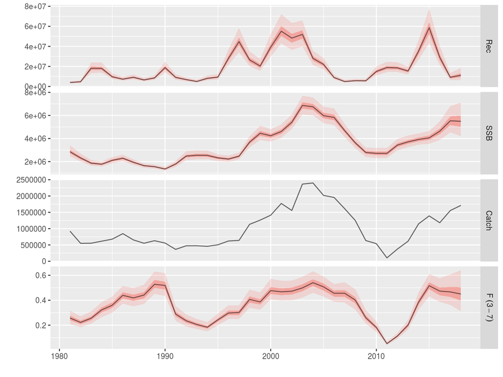

```r
plot(om)
```

**Figure 1** Blue whiting with assessment with estimation error.

## Dynamics

The assessment includes the biological parameters and selection pattern. These can be extracted from the ‘FLStock’ object and plotted using ‘ggplot2’.

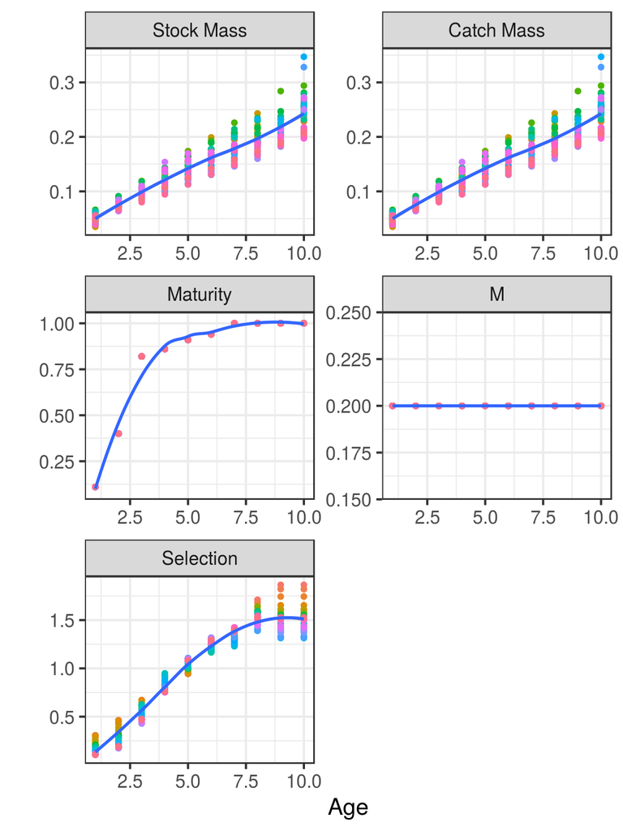

```r
dat=as.data.frame(FLQuants(om1,
                  stock.wt=stock.wt,
                  catch.wt=catch.wt,
                  m=m,
                  mat=mat,
                  sel=function(x)harvest(om1)%/%fbar(om1)),drop=T)

dat$qname=factor(dat$qname,levels=c("stock.wt","catch.wt","mat","m","sel"),
                           labels=c("Stock Mass",
                                    "Catch Mass",
                                    "Maturity",
                                    "M",
                                    "Selection"))
ggplot(dat)+
  geom_point( aes(age,data,col=ac(year),group=year))+
  geom_smooth(aes(age,data),method="loess")+
  facet_wrap(~qname,scale="free",ncol=2)+
  xlab("Age")+ylab("")+
  theme_bw(16)+
  theme(legend.position="none")
```

**Figure 2** Vectors-at-age.

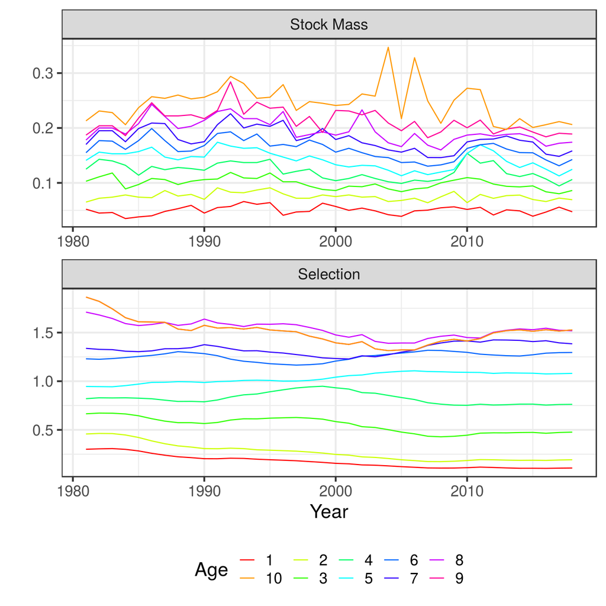

```r
ggplot(data=subset(dat,(qname%in%c("Stock Mass","Selection"))))+
  geom_line(aes(year,data,group=age,col=ac(age)))+
  facet_wrap(~qname,scale="free",ncol=1)+
  xlab("Year")+ylab("")+
  theme_bw(18)+
  theme(legend.position="bottom")+
  scale_color_manual("Age",values=rainbow(10))
```

**Figure 3** Time series of mass and selection-at-age

The dynamics are characterised by variability in recruitment that affects year class strength.

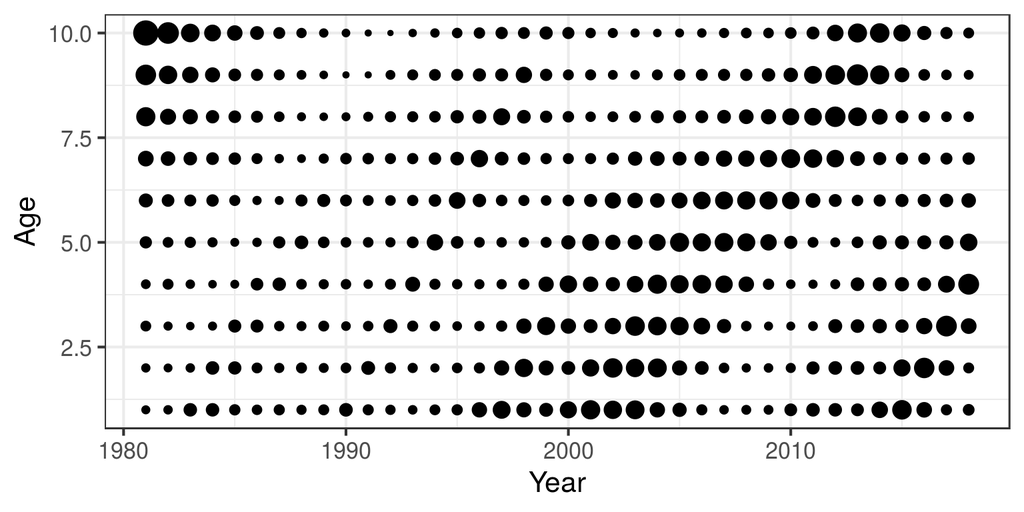

```r
dat=stock.n(om1)%/%apply(stock.n(om1),1,mean)
ggplot(as.data.frame(dat))+
  geom_point(aes(year,age,size=data))+
  theme_bw(16)+
  theme(legend.position="none")+
  xlab("Year")+ylab("Age")
```

**Figure 4** Cohort effects for stock numbers-at-age, scaled by mean by age.

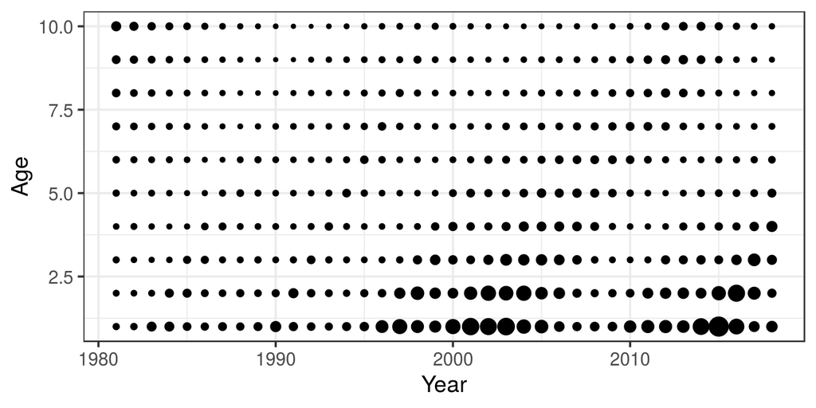

```r
dat=dat%/%(harvest(om1)%/%fbar(om1))
ggplot(as.data.frame(dat))+
  geom_point(aes(year,age,size=data))+
  theme_bw(16)+
  theme(legend.position="none")+
  xlab("Year")+ylab("Age")
```

**Figure 5** Cohort effects for exploitable numbers-at-age, stock numbers in Figure 4 scaled by selection pattern.

To explore whether dynamics are driven by recruitment of by SSB, the cross correlations between recruitment and SSB are plotted. If recruitment is driven by SSB then there should be a lag of +1 between SSB and $N_{1}$, however, the largest lags are negative indicating that SSB is driven by incoming year classes.

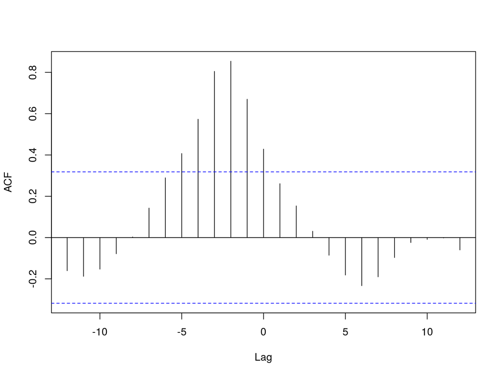

```r
ccf(c(rec(om1)),c(ssb(om1)),main="")
```

**Figure 6** Cross correlation between recruitment and SSB.

A similar phenomenon is seen for exploitable biomass, but the lag is less due to the fishery exploiting immature ages.

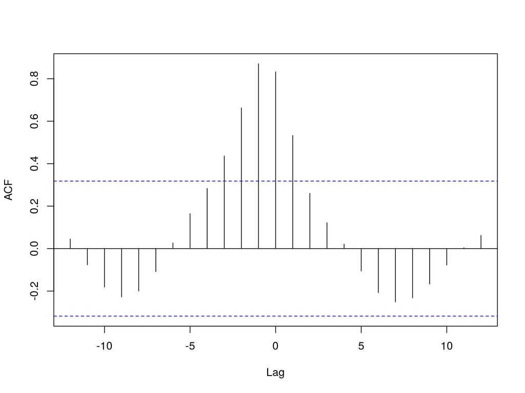

```r
esb    =function(x) apply((stock.n(x)%*%stock.wt(x))%/%
                                         (harvest(x)%/%fbar(x)),c(2,6),sum)
ccf(c(rec(om1)),c(esb(om1)),main="")
```

**Figure 7** Cross correlation between recruitment and exploitable biomass.